# Coursera Data Science Capstone Project

Sergios Koutavidis  
29/12/2016

Scope of this presentation is to describe the way this predictive application works and what options users have.

This is the final assignment for the Capstone project of Data Science Specialization

### Designing of this solution

- US Dataset provided had to cleaned up , punctuation , special characters and non-English characters had to be removed
- All words should be presented in lowercase while numbers and years should be categorized properly.
- A list of profanity words was used from a website to remove these appropriate words
- The full dataset was too big to be fully processed hence the biggest available subset was selected through R functions
- Next step involves tokenization and creation of n-grams
- Based on our model design , 4 n-grams have been created that predict words according to the number of words typed.

### Screenshots

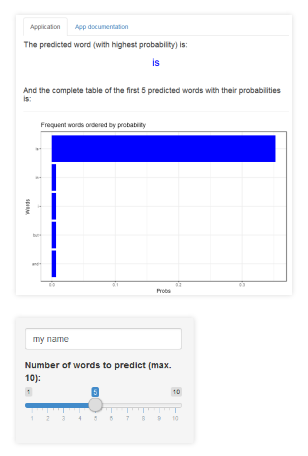

This is a screenshot of the application showing the input field, slider and bar chart indicating the predicted word ordered by probability.

Above screenshot is the result section where the word with the highest probability is shown along with the bar chart

Below screensot shows the input field where sentences are typed along with the slider that determines the number of words that will be shown in the bar chart.

### Additional information

This app is hosted on [ShinyApps.io](https://sergiosck.shinyapps.io/Word_Predict_Final/).

App files (ui.R and Server.R), n-grams files used in the app and rest of R script can be found at [GitHub](https://github.com/sergiosk/Coursera-Data-Science-Capstone-Project).

R Presentation is available at [RPubs](http://rpubs.com/sergiosck/238407).